# Case study and typical operations with base R

Advanced R

Wednesday May 3, 2017

## Learning goals

1. Overview of data from mass spectrometry-based proteomics experiments.
2. Basic data analysis with tools in base R.

## A typical MS-based proteomics experiment

- Design: comparison of **protein** abundance between **groups** of interest (e.g., healthy vs. diseased subjects).
- Measurements: **peptide features** profiled using **mass spectrometry**
  - **Proteins** are cleaved into peptides.
  - **Peptides** are charged, fragmented and measured by mass spectrometry.
  - **Features** (fragments of charged peptides) are the basic unit of quantification.

```r
load("../data/adv-R-twin.RData")
```

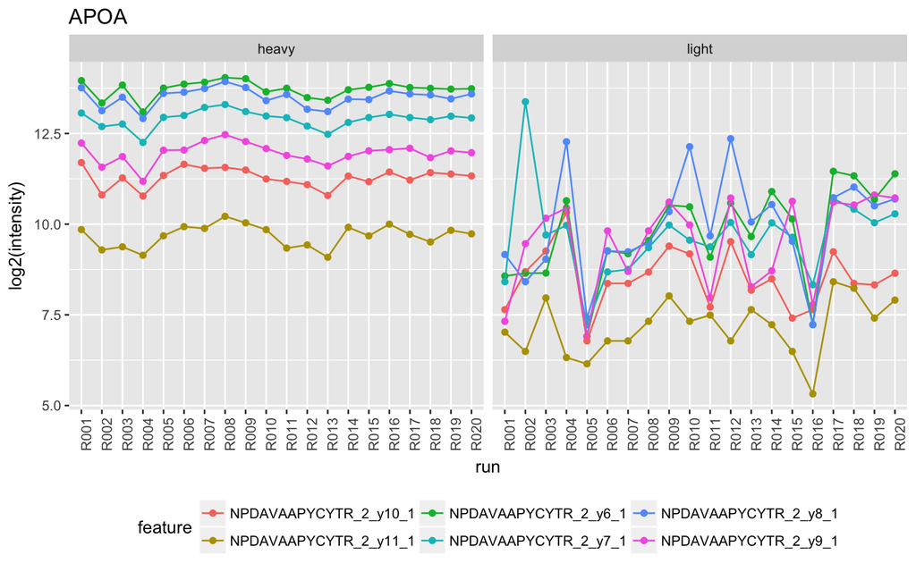

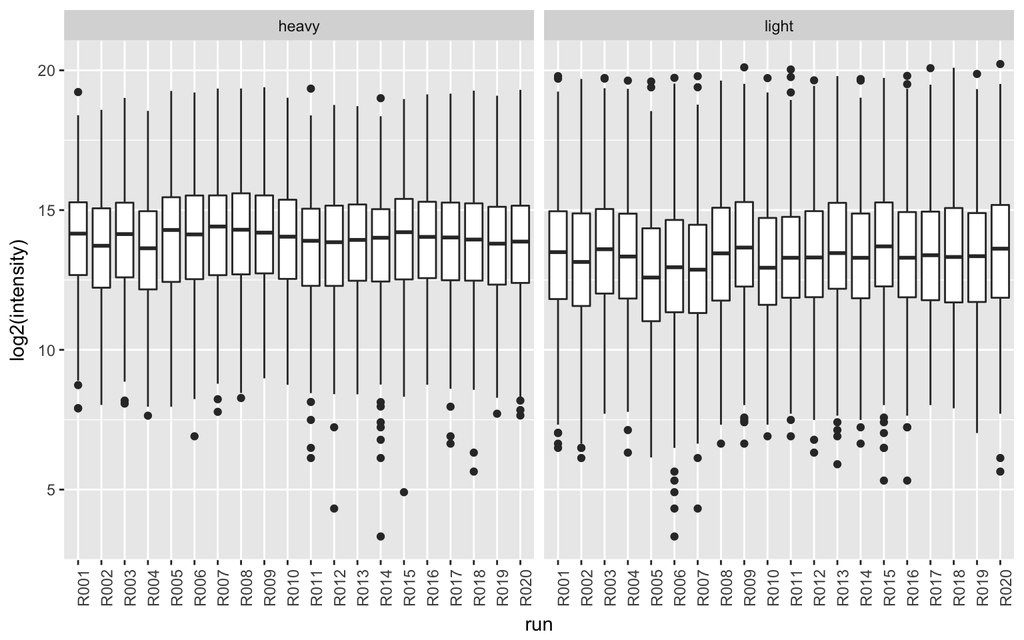

## Case study

Liu et al., Quantitative variability of 342 plasma proteins in a human twin population, *Molecular Systems Biology*, 2015. [PMID: 25652787]

- 232 MS runs of plasma samples:
  - 58 pairs of monozygotic (MZ) and dizygotic (DZ) twins.
  - 2 time points.
  - $58 \times 2 \times 2 = 232$.
- Data acquired with MS workflows of:
  - Data independent acquisition (DIA).
  - Selected reaction monitoring (SRM).
- Subset of the original dataset (with 33 proteins by DIA and 39 proteins by SRM).

```r
str(twin_dia)
```

```
## 'data.frame':    103936 obs. of  9 variables:
##  $ protein    : chr  "A1AG_BOVINE" "A1AG_BOVINE" "A1AG_BOVINE" "A1AG_BOVINE" ...
##  $ feature    : chr  "AIQAAFFYLEPR_2_y3_1" "AIQAAFFYLEPR_2_y3_1" "AIQAAFFYLEPR_2_y3_1" "AIQAAFFYLEPR_2_y3_1" ...
##  $ run        : chr  "R001" "R002" "R003" "R004" ...
##  $ pair       : int  1 1 1 1 2 2 2 2 3 3 ...
##  $ zygosity   : Factor w/ 2 levels "DZ","MZ": 2 2 2 2 2 2 2 2 2 2 ...
##  $ subject    : int  1 1 2 2 3 3 4 4 5 5 ...
##  $ visit      : int  1 2 1 2 1 2 1 2 1 2 ...
##  $ intensity_h: num  NA NA NA NA NA NA NA NA NA NA ...
##  $ intensity_l: num  27742 31572 24084 33134 23468 ...
```

The two data frames have the same format, containing 9 columns:

- `protein` (chr): protein name.
- `feature` (chr): combination of peptide, precursor charge state, fragment ion, and product charge state, separated by `_`.
- `run` (chr): MS run identifier (R001-R232).
- `pair` (int): pair identifier number (1-58).
- `zygosity` (factor): zygosity (MZ, DZ).
- `subject` (int): subject identifier number (1-116).
- `visit` (int): time of visit (1, 2).
- `intensity_l` (num): integrated feature intensity from light (L) channel.
- `intensity_h` (num): integrated feature intensity from heavy (H, aka reference) channel.

```r
head(twin_dia)
```

```
##       protein             feature  run pair zygosity subject visit
## 1 A1AG_BOVINE AIQAAFFYLEPR_2_y3_1 R001    1       MZ       1     1
## 2 A1AG_BOVINE AIQAAFFYLEPR_2_y3_1 R002    1       MZ       1     2
## 3 A1AG_BOVINE AIQAAFFYLEPR_2_y3_1 R003    1       MZ       2     1
## 4 A1AG_BOVINE AIQAAFFYLEPR_2_y3_1 R004    1       MZ       2     2
## 5 A1AG_BOVINE AIQAAFFYLEPR_2_y3_1 R005    2       MZ       3     1
## 6 A1AG_BOVINE AIQAAFFYLEPR_2_y3_1 R006    2       MZ       3     2
##   intensity_h intensity_l
## 1          NA       27742
## 2          NA       31572
## 3          NA       24084
## 4          NA       33134
## 5          NA       23468
## 6          NA       27247
```

```r
class(twin_dia)
```

```
## [1] "data.frame"
```

A **data frame** contains **variables** (in the **columns**) and **observations** (in the **rows**) in a tabular form. The columns in a data frame have the same length, but they may represent different types of variables (e.g., numeric, character, logical, etc.). Many functions for statistical modeling and inference in R presume data frames.

Dimension of the data:

```r
dim(twin_dia)
nrow(twin_dia)
ncol(twin_dia)
```

Level of the categorical variable:

```r
levels(twin_dia$pair)
levels(twin_dia$sample)
levels(twin_dia$label)
```

`View()` calls the data viewer in RStudio.

```r
View(twin_dia)
```

## Data analysis tasks for the case study

- **Task 1:** compute median of log-intensities for features from heavy channel in each run.
- **Task 2:** normalization of feature intensities to remove systematic bias across runs.
- **Task 3:** summarization of feature intensities for each protein in every run.
- **Task 4:** fit a linear model characterizing the summarized intensities.
- **Task 5:** group comparison using model-based inference.

We will discuss tools for wrangling data, making grouped summaries, merging data, etc. While R offers several options for each task, it is crucial to note how these approaches can (or cannot) be integrated into a consistent workflow.

## Task 1: median of log-intensities per run

We will discuss tools for data wrangling and making grouped summaries along this line.

### Data wrangling

- Reshape a dataset (without changing its content):
  - Rename the columns of a data frame.
  - Reorder rows by values of a column.
- Data manipulation and transformation (with `$`, indexing, logical operations):
  - Extract existing variables.
  - Extract existing observations.
  - Derive new variables.

#### Rename variables

Fix typos, follow naming convention, rename columns of a data frame retuned by another function.

```r
colnames(twin_dia)
```

```
## [1] "protein"     "feature"     "run"         "pair"        "zygosity"
## [6] "subject"     "visit"       "intensity_h" "intensity_l"
```

```r
# colnames(twin_dia) <- c("Protein", "Feature", "Pair", "Sample", "IntensityH", "IntensityL")
```

#### Extract existing variables

To extract observations based on values in specific columns, or keep only a subset of variables relevant to the analysis.

```r
design <- unique(twin_dia[, c("run", "pair", "zygosity", "subject")])
head(design)
```

```
##    run pair zygosity subject
## 1 R001    1       MZ       1
## 2 R002    1       MZ       1
## 3 R003    1       MZ       2
## 4 R004    1       MZ       2
## 5 R005    2       MZ       3
## 6 R006    2       MZ       3
```

#### Extract existing observations with logical operations

```r
# Exclude rows with NA in column intensity_h
sub_dia <- twin_dia[!is.na(twin_dia$intensity_h), ]
head(sub_dia)
```

```
##      protein                           feature  run pair zygosity subject
## 6729    A2MG SSSNEEVM(UniMod_35)FLTVQVK_2_y4_1 R001    1       MZ       1
## 6730    A2MG SSSNEEVM(UniMod_35)FLTVQVK_2_y4_1 R002    1       MZ       1
## 6731    A2MG SSSNEEVM(UniMod_35)FLTVQVK_2_y4_1 R003    1       MZ       2
## 6732    A2MG SSSNEEVM(UniMod_35)FLTVQVK_2_y4_1 R004    1       MZ       2
## 6733    A2MG SSSNEEVM(UniMod_35)FLTVQVK_2_y4_1 R005    2       MZ       3
## 6734    A2MG SSSNEEVM(UniMod_35)FLTVQVK_2_y4_1 R006    2       MZ       3
##      visit intensity_h intensity_l
## 6729     1        6687        1275
## 6730     2        5799        1345
## 6731     1        6093        1377
## 6732     2        6049        1727
## 6733     1        7068         922
## 6734     2        5401         720
```

Combine multiple logical operations:

- Element-wise AND operation with `&`.
- Element-wise OR operation with `|`.

```r
# Filter based on columns intensity_h and run
sub_dia <- twin_dia[!is.na(twin_dia$intensity_h) & twin_dia$run == "R001", ]
head(sub_dia)
```

```
##      protein                           feature  run pair zygosity subject
## 6729    A2MG SSSNEEVM(UniMod_35)FLTVQVK_2_y4_1 R001    1       MZ       1
## 6961    A2MG SSSNEEVM(UniMod_35)FLTVQVK_2_y5_1 R001    1       MZ       1
## 7193    A2MG SSSNEEVM(UniMod_35)FLTVQVK_2_y7_1 R001    1       MZ       1
## 7425    A2MG SSSNEEVM(UniMod_35)FLTVQVK_2_y8_1 R001    1       MZ       1
## 7657    A2MG SSSNEEVM(UniMod_35)FLTVQVK_2_y9_1 R001    1       MZ       1
## 7889    A2MG           SSSNEEVMFLTVQVK_2_y10_1 R001    1       MZ       1
##      visit intensity_h intensity_l
## 6729     1        6687        1275
## 6961     1       11720        2485
## 7193     1        4791        1144
## 7425     1        6496        1457
## 7657     1        4615        1074
## 7889     1        2464        1630
```

#### Make new variables

```r
# Log2 transformation
twin_dia$log2inty_h <- log2(twin_dia$intensity_h)
twin_dia$log2inty_l <- log2(twin_dia$intensity_l)
```

### Combine multiple operatons

Compute the median of feature intensities from heavy channel (`log2inty_h`) in one run (`R001`).

```r
median(twin_dia$log2inty_h[!is.na(twin_dia$log2inty_h) & twin_dia$run == "R001"])
```

```
## [1] 14.15806
```

- The name of the data frame is repeated several times. This can be avoided by using `with()`, as in `with(twin_dia, median(log2inty_h[!is.na(log2inty_h) & run == "R001"]))`.
- The combined operations are defined with a **nested representation**. The flow becomes less readable when combining several operations. Creating intermediate objects may be helpful if the objects are named properly (naming itself can be hard though).

### Split-Apply-Combine

A very common pattern to make grouped summaries:

- **Split** a vector `X` into subsets defined by a factor vector `GROUP`.
- **Apply** function `FUN` to each subset.
- **Combine** and return the result in a convenient form.

To compute the medians of log-intensities in all runs, we need to split the column vector `log2inty_h` into subsets defined by `run`, apply `median()` to each subset, and combine the results.

### Approach 1: use a `for()` loop

```r
# Approach 1
runs <- unique(twin_dia$run)

medians <- rep(0, length(runs))  # create a vector to restore the result
for (i in seq_along(runs)) {
    medians[i] <- median(twin_dia$log2inty_h[twin_dia$run == runs[i]], na.rm = TRUE)
}
str(medians)
```

```
##  num [1:232] 14.2 13.7 14.1 13.6 14.3 ...
```

### Approach 2: use `tapply()`, as in `tapply(X, GROUP, FUN)`

```r
# Approach 2
medians <- tapply(twin_dia$log2inty_h, twin_dia$run, median, na.rm = TRUE)
head(medians)  # a named vector is returned
```

```
##     R001     R002     R003     R004     R005     R006
## 14.15806 13.72355 14.14139 13.63368 14.28807 14.12904
```

### Approach 3: use `aggregate()`, as in `aggregate(X, GROUP, FUN)`

```r
# Approach 3
df_median <- aggregate(twin_dia$log2inty_h, list(run = twin_dia$run), median, na.rm = TRUE)
head(df_median)  # a data frame is returned
```

```
##    run        x
## 1 R001 14.15806
## 2 R002 13.72355
## 3 R003 14.14139
## 4 R004 13.63368
## 5 R005 14.28807
## 6 R006 14.12904
```

```r
# Rename second column for later use
colnames(df_median)[2] <- "run_median"
```

`tapply()` and `aggregate()` are tools for **functional programming** that will be discussed in greater detail in a later section. Note that their outputs are of different classes.

## Task 2: normalization

Adjust the log-intensities to equalize the medians across runs to a global median:

```r
(gbl_median <- median(medians, na.rm = TRUE))
```

```
## [1] 14.04896
```

### Approach 1: use a `for()` loop

```r
# Use a for loop
for (ii in names(medians)) {
    log2inty_h <- twin_dia$log2inty_h[twin_dia$run == ii]
    log2inty_l <- twin_dia$log2inty_l[twin_dia$run == ii]
    twin_dia$log2inty_h[twin_dia$run == ii] <- log2inty_h - medians[ii] + gbl_median
    twin_dia$log2inty_l[twin_dia$run == ii] <- log2inty_l - medians[ii] + gbl_median
}
```

### Approach 2: use a vectorized representation

A more efficient way is to use a vectorized representation with the named vector returned by `tapply()`:

```r
# This gives the medians of runs 001_MZ_1, 002_MZ_1, 001_MZ_1
medians[c("R001", "R002", "R003")]
```

```
##     R001     R002     R003
## 14.15806 13.72355 14.14139
```

```r
# Use vectorized representation to normalize the dataset
twin_dia$log2inty_h <- twin_dia$log2inty_h - medians[twin_dia$run] + gbl_median
twin_dia$log2inty_l <- twin_dia$log2inty_l - medians[twin_dia$run] + gbl_median
```

### Approach 3: use `merge()`

We can also add one additional column for the median in each run to the original dataset `twin_dia`, with `df_median` returned by `aggregate()`.

Use `merge()` to merge two data frames according to common columns, as in: `merge(x, y, by.x = "x_col", by.y = "y_col")`, to join two data frames `x`, `y`, by matching the columns `x_col` and `y_col`.

- Default (when `by.x`, `by.y` not specified) is to match all columns with common names.
- Output will be a new data frame that has all the columns of both data frames.

```r
twin_dia2 <- merge(x = twin_dia, y = df_median)
head(twin_dia2)
```

```
##    run     protein                           feature pair zygosity subject
## 1 R001 A1AG_BOVINE               AIQAAFFYLEPR_2_y3_1    1       MZ       1
## 2 R001        TTHY             GSPAINVAVHVFR_3_y11_3    1       MZ       1
## 3 R001 A1AG_BOVINE                 EHFVDLLLSK_2_y9_2    1       MZ       1
## 4 R001        A2MG SSSNEEVM(UniMod_35)FLTVQVK_2_y9_1    1       MZ       1
## 5 R001         IC1         GVTSVSQIFHSPDLAIR_3_y14_2    1       MZ       1
## 6 R001       APOA1              DYVSQFEGSALGK_2_y9_1    1       MZ       1
##   visit intensity_h intensity_l log2inty_h log2inty_l run_median
## 1     1          NA       27742         NA  14.541580   14.15806
## 2     1       33067      105041   14.79490  16.462388   14.15806
## 3     1          NA        2220         NA  10.898139   14.15806
## 4     1        4615        1074   11.95391   9.850574   14.15806
## 5     1       33692       21186   14.82191  14.152619   14.15806
## 6     1       63146      127581   15.72820  16.742849   14.15806
```

```r
twin_dia2$log2inty_h <- twin_dia2$log2inty_h - twin_dia2$run_median + gbl_median
twin_dia2$log2inty_l <- twin_dia2$log2inty_l - twin_dia2$run_median + gbl_median
```

## Task 3: summarization of feature intensities

For each **protein** in every **run**, compute the **log of the sum** of the feature intensities.

```r
# Transform the normalized log-intensities back to the original scale
twin_dia$intensity_h <- 2 ^ (twin_dia$log2inty_h)
twin_dia$intensity_l <- 2 ^ (twin_dia$log2inty_l)
```

### Approach 1: use two nested `for()` loops

One for protein and the other for run.

### Approach 2: use `tapply()`

Use `tapply()` with grouping variables defined in a **list**:

```r
# Approach 2
sum_t <- tapply(
    twin_dia$intensity_l,
    list(run = twin_dia$run, protein = twin_dia$protein),
    function(x) log2(sum(x, na.rm = TRUE))
    )
head(sum_t)
```

```
##       protein
## run    A1AG_BOVINE     A2MG     AACT      APOA    APOA1     APOB     APOE
##   R001    18.18103 16.42417 17.85047 10.582695 22.42684 15.78041 16.66557
##   R002    18.56897 17.24572 17.78143 14.268499 23.14140 17.56391 17.79064
##   R003    18.34523 16.51348 18.03998 11.694716 22.45365 15.90535 16.77347
##   R004    18.96922 17.73880 18.20516 14.162174 23.23576 17.66656 18.03159
##   R005    17.50999 15.64802 16.68668  9.055094 21.67371 14.79224 15.20909
##   R006    18.37304 15.64610 17.35422 11.381408 22.12333 15.94059 16.55856
##       protein
## run        C1QA     C1QB     C1QC     CFAB     CLUS      CO3     CO4A
##   R001 15.01845 16.78656 14.68643 18.44719 17.67519 19.00915 17.86077
##   R002 15.31969 18.15143 14.65599 19.45774 18.50715 20.98190 18.58914
##   R003 14.86698 16.52896 14.37708 18.47846 17.92876 19.82211 17.93704
##   R004 16.00283 17.04366 15.27551 19.51094 18.75322 21.21799 18.94303
##   R005 13.57297 14.33173 13.26943 17.32458 16.63015 18.32277 16.86071
##   R006 13.56849 16.79388 11.61790 18.09033 17.41989 19.34051 17.72654
##       protein
## run         CO5      CO6      CO7      FN1     GELS      HPT      IC1
##   R001 16.80517 14.90341 12.96636 15.61483 17.58402 21.93719 17.37457
##   R002 16.52477 14.80467 13.54676 16.27211 17.77562 22.63103 18.94211
##   R003 16.87380 15.04928 13.24650 15.69591 17.58942 22.23258 17.58525
##   R004 17.58500 15.13883 13.89597 16.47757 18.24699 22.80021 19.13786
##   R005 15.62239 13.42188 11.55312 14.74648 16.61843 20.64945 17.53182
##   R006 16.17097 14.11929 11.80597 15.27924 17.07604 20.79286 18.01375
##       protein
## run       ITIH4     PLMN     PON1      PZP     RET4     SHBG     TETN
##   R001 17.03984 18.09571 16.62677 19.79958 15.29762 13.34702 15.06626
##   R002 17.73448 18.81254 17.31457 19.96343 15.44603 14.62898 15.39674
##   R003 17.35425 18.09593 16.50524 19.86534 15.57668 13.47691 15.20224
##   R004 17.97203 19.11759 17.72457 20.58892 16.03207 14.67585 15.47627
##   R005 15.82042 16.84116 15.60966 19.11786 13.88802 13.61543 14.13831
##   R006 16.42461 17.54542 16.51999 19.44151 14.49116 12.60179 14.50572
##       protein
## run        THBG     THRB     TRFE     TTHY     VTNC
##   R001 12.12997 18.88935 21.80194 18.26844 19.38733
##   R002 13.06469 18.86040 22.20709 18.43010 20.11820
##   R003 12.70407 18.98904 21.92493 18.41316 19.37431
##   R004 13.52317 18.91147 22.41099 19.22887 20.03338
##   R005 10.99496 17.65925 21.13725 16.63124 18.03080
##   R006 12.18190 18.07897 21.82223 17.55760 18.79710
```

### Approach 3: use `aggregate()`

```r
# Approach 3
sum_g <- aggregate(
    twin_dia$intensity_l,
    list(run = twin_dia$run, protein = twin_dia$protein),
    function(x) log2(sum(x, na.rm = TRUE))
)
head(sum_g)
```

```
##    run     protein        x
## 1 R001 A1AG_BOVINE 18.18103
## 2 R002 A1AG_BOVINE 18.56897
## 3 R003 A1AG_BOVINE 18.34523
## 4 R004 A1AG_BOVINE 18.96922
## 5 R005 A1AG_BOVINE 17.50999
## 6 R006 A1AG_BOVINE 18.37304
```

```r
# Alternatively, use a formula representation
aggregate(
    intensity_l ~ run + protein,
    data = twin_dia,
    function(x) log2(sum(x, na.rm = TRUE))
)
```

```r
# Rename the third column
colnames(sum_g)[3] <- "log2inty"
```

Saving grouped summaries in a data frame makes it easier to carry out statistical modeling and inference in subsequent analysis.

## Task 4: statistical modeling

For each **protein**, fit a linear model, extract summaries of the fitted model, and draw model-based conclusions.

### Fit a linear regression model with `lm()`

The first argument of `lm()` is a formula, e.g., `Y ~ X1 + X2`, where `Y` is the response and `X1`, `X2` are the predictive variables. These refer to the column names (variables) in a data frame, that we pass in `lm()` through the `data` argument.

Suppose we are interested in knowing if the abundance of one **protein** is associated with **zygosity**.

```r
# Merge the design information
df_sum <- merge(sum_g, design)
head(df_sum)
```

```
##    run     protein log2inty pair zygosity subject
## 1 R001 A1AG_BOVINE 18.18103    1       MZ       1
## 2 R001        APOB 15.78041    1       MZ       1
## 3 R001        CLUS 17.67519    1       MZ       1
## 4 R001         CO7 12.96636    1       MZ       1
## 5 R001        PLMN 18.09571    1       MZ       1
## 6 R001        TETN 15.06626    1       MZ       1
```

```r
sub_sum <- df_sum[df_sum$protein == "A2MG", ]  # Subset for protein A2MG
fit <- lm(log2inty ~ zygosity, data = sub_sum)
```

```r
# Same as
fit <- lm(log2inty ~ zygosity, data = df_sum, subset = df_sum$protein == "A2MG")
```

```r
class(fit)
```

```
## [1] "lm"
```

### Utility functions

R offers a couple of utility functions for linear models, such as `coef()`, `fitted()`, `residuals()`, `summary()`, `predict()`, for retrieving coefficients, fitted values, residuals, model summary, making predictions with the model, respectively.

These functions can be applied in the same way for model objects from `glm()`, `gam()`, etc.

#### Use `summary()` to display an overview of the fitted model

```r
summary(fit)
```

```
##
## Call:
## lm(formula = log2inty ~ zygosity, data = sub_sum)
##
## Residuals:
##     Min      1Q  Median      3Q     Max
## -3.4281 -0.6653  0.1787  0.6487  1.8491
##
## Coefficients:
##             Estimate Std. Error t value Pr(>|t|)
## (Intercept)  16.1734     0.0982 164.703  < 2e-16 ***
## zygosityMZ    0.3366     0.1246   2.701  0.00743 **
## ---
## Signif. codes:  0 '***' 0.001 '**' 0.01 '*' 0.05 '.' 0.1 ' ' 1
##
## Residual standard error: 0.9212 on 230 degrees of freedom
## Multiple R-squared:  0.03074,    Adjusted R-squared:  0.02652
## F-statistic: 7.294 on 1 and 230 DF,  p-value: 0.007434
```

```r
# More detail
str(summary(fit))
```

#### Use `coef()` to retrieve estimated coefficients

```r
coef(fit)
```

```
## (Intercept)  zygosityMZ
##  16.1733831   0.3366225
```

#### Use `fitted()` to retrieve fitted values

```r
head(fitted(fit))
```

```
##       29       47       90      117      162      194
## 16.51001 16.51001 16.51001 16.51001 16.51001 16.51001
```

It is not very easy to develop general workflow deriving summaries for all the proteins. Without defining specialized functions to extract information on various aspects (which can be called by `tapply()` or `aggregate()`), we are mostly left off with iterations due to

- more complicated/involved operations
- complex output objects.

## Task 5: model-based inference

Two-sample $t$-test

```r
ttest <- t.test(log2inty ~ zygosity, data = sub_sum)
ttest
```

```
##
##  Welch Two Sample t-test
##
## data:  log2inty by zygosity
## t = -2.616, df = 165.6, p-value = 0.00972
## alternative hypothesis: true difference in means is not equal to 0
## 95 percent confidence interval:
##  -0.59068600 -0.08255909
## sample estimates:
## mean in group DZ mean in group MZ
##         16.17338         16.51001
```

Alternative, use the `subset` option:

```r
t.test(log2inty ~ zygosity, data = df_sum, subset = df_sum$protein == "A2MG")
```

Use two vectors for the two samples:

```r
t.test(x = sub_sum$log2inty[sub_sum$zygosity == "DZ"], y = sub_sum$log2inty[sub_sum$zygosity == "MZ"])
```

The output object is again quite complex.

```r
str(ttest)
```

```
## List of 9
##  $ statistic  : Named num -2.62
##   ..- attr(*, "names")= chr "t"
##  $ parameter  : Named num 166
##   ..- attr(*, "names")= chr "df"
##  $ p.value    : num 0.00972
##  $ conf.int   : atomic [1:2] -0.5907 -0.0826
##   ..- attr(*, "conf.level")= num 0.95
##  $ estimate   : Named num [1:2] 16.2 16.5
##   ..- attr(*, "names")= chr [1:2] "mean in group DZ" "mean in group MZ"
##  $ null.value : Named num 0
##   ..- attr(*, "names")= chr "difference in means"
##  $ alternative: chr "two.sided"
##  $ method     : chr "Welch Two Sample t-test"
##  $ data.name  : chr "log2inty by zygosity"
##  - attr(*, "class")= chr "htest"
```

```r
ttest$estimate
```

```
## mean in group DZ mean in group MZ
##         16.17338         16.51001
```

```r
ttest$statistic
```

```
##         t
## -2.615981
```

```r
ttest$p.value
```

```
## [1] 0.009719549
```

It is therefore not very easy to generalize. How would you implement a workflow to summarize the means of two groups, difference, $t$-statistic, $p$-value in every protein?